# Rvis02 ggplot2

Sunday, February 01, 2015

## ggplot2

- Leland Wilkinson **“The Grammar of Graphics”**
- 데이터 그래픽을 어떻게 기술하는지에 대해 형식적이고 구조적인 시각을 취하고 있다

## Data Graphic

- 데이터의 속성들을 그래픽의 시각적인 속성들에 대입(또는 대응) 한다.
- 보통 데이터 속성은 수치형 / 범주형 변수
- 시각적인 속성은 점의 X, Y 위치, 선의 색깔, 막대의 높이 등

## Data Graphic : R 기본함수의 경우

- 데이터 속성을 시각적 속성에 대입하는 방법이 때에 따라 다르다
- 대입을 바꾸려면 데이터 자체의 구조를 바꿔야 할 때도 있다
- 완전히 새로운 커맨드를 입력하기도 한다.
- 구조도 바꾸고 커맨드도 새로 쓰기도 한다……

## Data Graphic : R 기본함수의 경우

```r
#install.packages("gcookbook")
library(gcookbook)
simpledat
```

```
##    A1 A2 A3
## B1 10  7 12
## B2  9 11  6
```

넓은 형식의 데이터(Wide Format)

## Data Graphic : R 기본함수의 경우

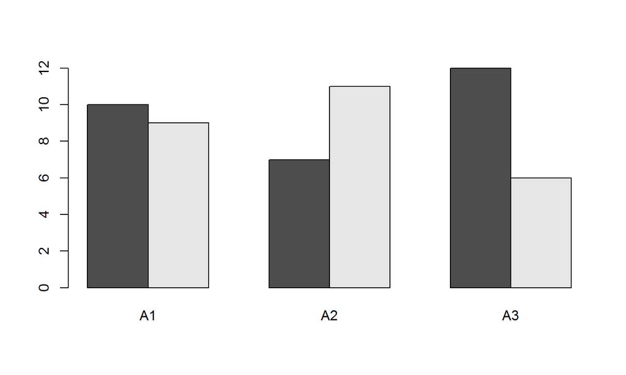

```r
barplot(simpledat, beside=TRUE)
```

## Data Graphic : R 기본함수의 경우

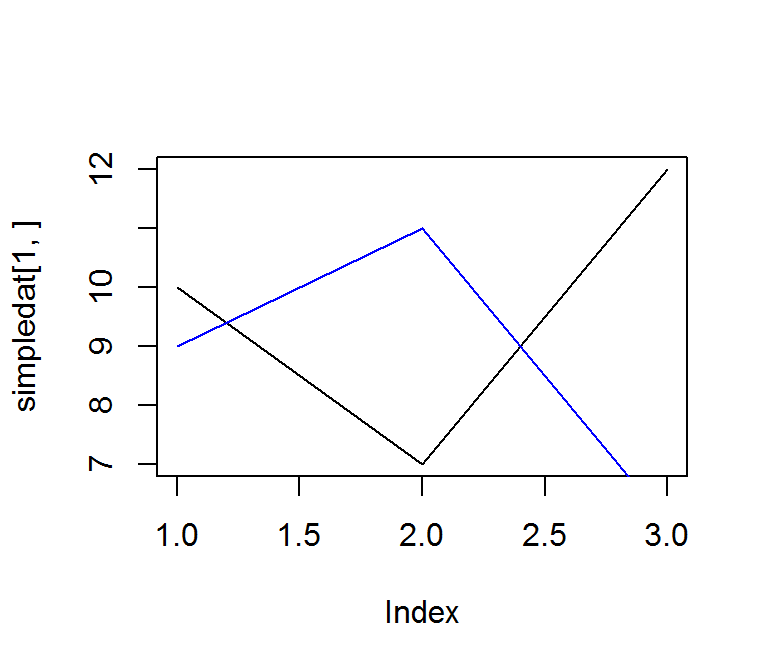

```r
plot(simpledat[1,] ,type = 'l')
lines(simpledat[2,], type = 'l', col = "blue")
```

- 막대 그래프와 선그래프를 만드는 방식이 **완전히** 다르다

## Data Graphic : ggplot2

```r
simpledat_long
```

```
##   Aval Bval value
## 1   A1   B1    10
## 2   A1   B2     9
## 3   A2   B1     7
## 4   A2   B2    11
## 5   A3   B1    12
## 6   A3   B2     6
```

- 필요한 데이터의 구조가 언제나 동일하다
- 긴 형식의 데이터(Long Format)
- *Tidy Data*

## Tidy Data ??

*Hadley Wickham*

- Tidy data is a standard way of mapping the meaning of a dataset to its structure
- A dataset is messy or tidy depending on how rows, columns and tables are matched up with observations, variables and types

## Tidy Data

*Codd’s 3rd normal form*

- Each variable forms a column
- Each observation forms a row
- Each type of observational unit forms a table

## ggplot2의 구성

```
##   Aval Bval value
## 1   A1   B1    10
## 2   A1   B2     9
## 3   A2   B1     7
## 4   A2   B2    11
## 5   A3   B1    12
## 6   A3   B2     6
```

- X = Aval
- fill = Bval
- Y = value
- 그래프의 형태 = **geom_bar**

## ggplot2의 구성

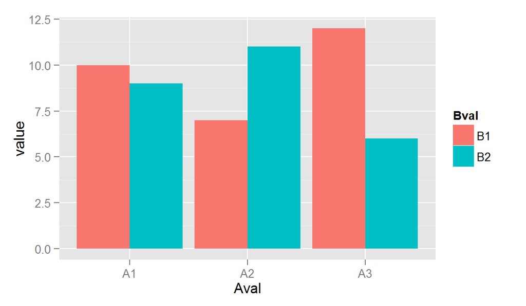

```r
#install.packages("ggplot2")
library(ggplot2)
ggplot(simpledat_long, aes(x = Aval, y = value, fill = Bval)) +
  geom_bar(stat = "identity", position = "dodge")
```

## ggplot2의 구성

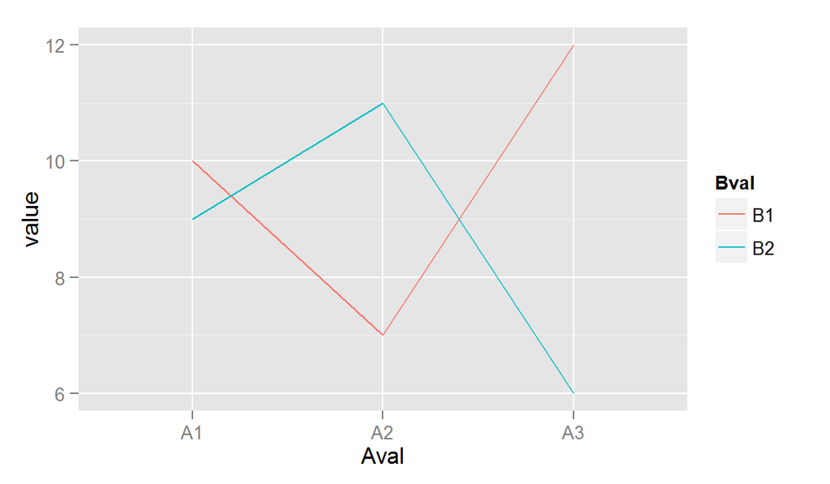

```r
ggplot(simpledat_long,
       aes(x = Aval, y = value, colour = Bval, group = Bval)) +
  geom_line()
```

## ggplot2의 구조 및 용어

- **데이터**는 우리가 시각화하고 싶은 대상.  
  **변수** *로 구성되어 있다*
- **도형(geom)** 은 데이터를 표현하기 위해 그리는 도형 객체.  
  *막대, 선, 점 등이 있다*
- **에스테틱 속성(aesthetics)**은 도형의 시각적인 속성.  
  *X 위치, Y 위치, 선 색상, 점 모양 등*
- 데이터 값을 에스테틱에 **대입(map)** 한다
- **척도(scale)**는 데이터 공간의 값들을 에스테틱 공간의 값들로  
  대입하는 과정을 제어한다.
- **가이드(guide)**는 독자가 시각적인 속성들을 데이터 공간으로 어떻게 대입해야 하는지 알려준다.  
  *눈금, 축 라벨 등*

## ggvis

- ggplot2와 비슷한 문법
- Rstudio 상에서 interactive 시각화를 구현함
- Shiny 패키지를 이용해 웹상에 퍼블리싱 가능
- 현재 0.4 version 변경 및 개선의 여지가 많다  
  (ggplot2는 2015년 1월부로 1.0 버전으로 안정화)

## ggvis : sample

```r
#install.packages("ggvis")
library(ggvis)
mtcars %>%
  ggvis(x = ~wt, y = ~mpg) %>%
  layer_points()
```

[output not shown]

## ggvis : sample

```r
# RStudio에서 하면 Interative Plot이 등장
mtcars %>%
  ggvis(~wt, ~mpg,
    size := input_slider(10, 100),
    opacity := input_slider(0, 1)
  ) %>%
  layer_points()
```